# README

Below scripts works using R 3.4, R 4.0 and python 3.7.4.

Note that the R scripts are not developed to be executed from command line. We recommend using RStudio for running these scripts. Modifications to these codes may be needed, to set input file directories, sample names, and other project specific information.

# scRNA-seq analysis for construction of multicellular network models (MNM) and prioritization of upstream regulatory (UR) genes

# Instructions for running the codes

The project is divided into 3 main parts

- Data preparation, and analyses for UR prediction and MNM construction, which can be run by the script bin/main.R.
- Ingenuity Pathway analysis. The detailed instructions for running the analyses follow below.
- Construction of multicellular network models (MNMs) and ranking of URs, which can be run by the script post_IPA.sh

## Data preparation, and analyses for UR prediction and MNM construction

The data can be processed by running the following script. The file creates the directory structure and calls the functions to run Quality assesment and full matrix construction, Cell type analysis and Differnetial expression analysis

```
dir.create("data")
dir.create("data/DEGS_with_Monocle")
dir.create("data/DEGS_with_Monocle/Matrix_in")
dir.create("data/DEGS_with_Monocle/Monocle_out")
dir.create("data/DEGS_with_Monocle/Monocle_out_withFCs")
dir.create("data/knn_smoothing")
dir.create("data/RCA_out")
dir.create("data/RCA_out/full_matrix")
dir.create("data/RCA_references")
dir.create("plot")

### Read data from GSE180697 and save it to data folder
filenames = c('data/GSE180697_SAR_patients_expression_matrix.csv.gz',
              'data/GSE180697_Healthy_controls_expression_matrix.csv.gz')

### Preprocess the data and remove outliers
source('sc_data_quality_sorting.R')
HA = sc_data_quality_sorting(filenames[1])
write.csv(HA, 'data/HA_min200genesPerCell_sorted_expression_matrix.csv', quote = F)
HC = sc_data_quality_sorting(filenames[2])
write.csv(HC, 'data/HC_min200genesPerCell_sorted_expression_matrix.csv', quote = F)

### Run knn smoothing
#system(chmod u+x run_knn_smoothing.sh)
system('./run_knn_smoothing.sh ')

### Run cell typing
source('RCA_reference_construction.R')
source('RCA_cellType_identification.R')
RCA_cellType_identification('HA')
#RCA_cellType_identification('HC')

### Run pre-DEG analysis
source('pre-DEG_analysis.R')
pre_DEG_analysis('HA')
#pre_DEG_analysis('HC')

### Run Monocle_v3_RAdata
source('Monocle_v3_RAdata.r')
Monocle_v3_RAdata('HA')
#Monocle_v3_RAdata('HC')

### Run sc_FC_zero_infl_neg-binomial
source('sc_FC_zero-infl-neg-bionmial.R')
sc_FC_zero_infl_neg_binomial('HA')
#sc_FC_zero_infl_neg_binomial('HC')

### Run plot_DEGs.R
source('plot_DEGs.R')
plots = plot_custom()
pdf('plot/lognDEGs_over_time.pdf')
plots[[1]]
dev.off()
pdf('plot/celltype_ratios_over_groups.pdf')
plots[[2]]
dev.off()
```

### Quality assesment and full matrix construction

To ensure good quality data for downstream analyses, it is recommended to remove poor quality cells from the analyses. Here, we define and keep the good quality cells as those having a minimum of 400 transcripts, 200 genes, and less than 20% mitochondrial genes. Due to the risk of duplicates in the library resulting in two or more cells sharing a cell barcode, it is also recommend to remove outliers, which can be based on empirical evaluation of the distributionan overestimation of transcripts count over the cells.

The expected input is for this part is a matrix with genes in rows and cells in columns. The quality of the data and removal of the outliers is done using sc_data_quality_sorting.R

### Cell type analysis

The references for cell type identification were created by RCA_reference_construction.R in R 3.4, and added to the RCA sysdata file installed. Input to this scripts are the normalized matrix output from microarray analyses based on which the references should be constructed.

RCA_cellType_identification.R is then run to map the cells towards the newly created references. As this script is based on some modifications to the Reference Component Analysis (RCA, Li et al., 2017 https://pubmed.ncbi.nlm.nih.gov/28319088/) with calculations of p-values and newly created references, the modified codes need to be added as well (as part of the script). These modified codes you can find in /RNA_mod/. As input matrix to this code we used the knn-smoothed data (output using script from Wagner et al., 2018 https://www.biorxiv.org/content/early/2018/04/09/217737), but any UMI-based expression matrix should work equally.

1. RCA_reference_construction.R # Build references for cell type identification
2. RCA_cellType_identification.R # Cell type identification using reference component analysis

### Differnetial expression analysis

To prepare the data from cell type analysis for differential expression analysis, we run pre-DEG_analysis.R. This script will ensure that the input to Monocle_v3_RAdata.r is is the correct format. It will also compute some basic statistics, such as the number of cells per sample (cell type, time point, etc).

Monocle_v3_RAdata.r is run to calculate differentially expressed genes (DEGs) between allergen challenged and non-challenged samples. Some modifications to the code are needed to compute DEGs between any other pair of groups.

The fold changes (FCs) for the DEGs, we calculate using sc_FC_zero-infl-neg-bionmial.R. This will compute FCs between allergen challenged vs non-challenged, meaning that a positive FC indicates a higher mean expression in the allergen challenged compared to the non-challenged group. Some modifications to the code are needed to compute the FCs between any other pair of groups.

We plot the distrinbution of DEGs over different time points and cell types (Fig 1), as well as the number of cell types over different time points and treatment groups (Fig 2), by plot_DEGs.R.

1. pre-DEG_analysis.R # statistics and preparation of input files for DEG analysis
2. Monocle_v3_RAdata.r # Calculate DEGs
3. sc_FC_zero-infl-neg-bionmial.R # FC calculations
4. plot_DEGs.R # Plot the distribution of DEGs

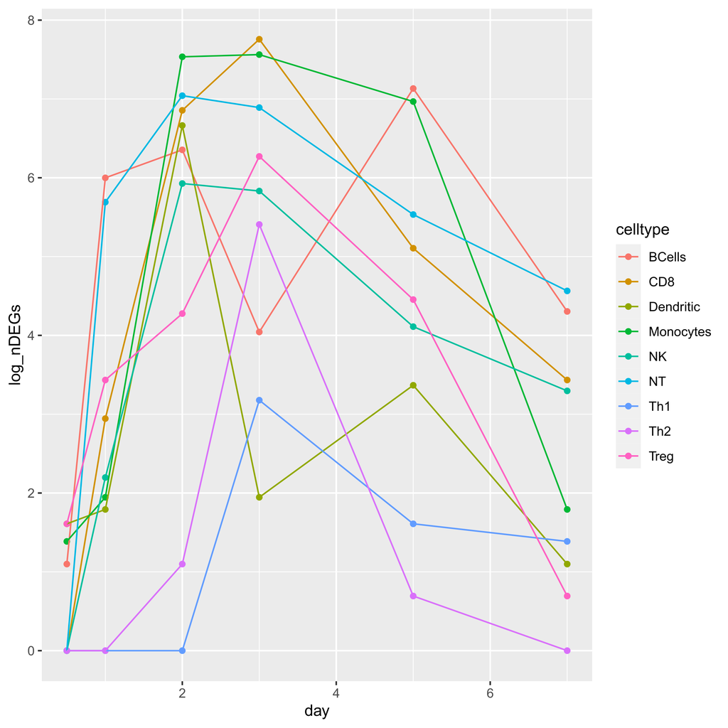

Fig 1. log(number of DEGs) identified between allergen-stimulated and diluent-stimulated cells, for each cell type at the different time points.

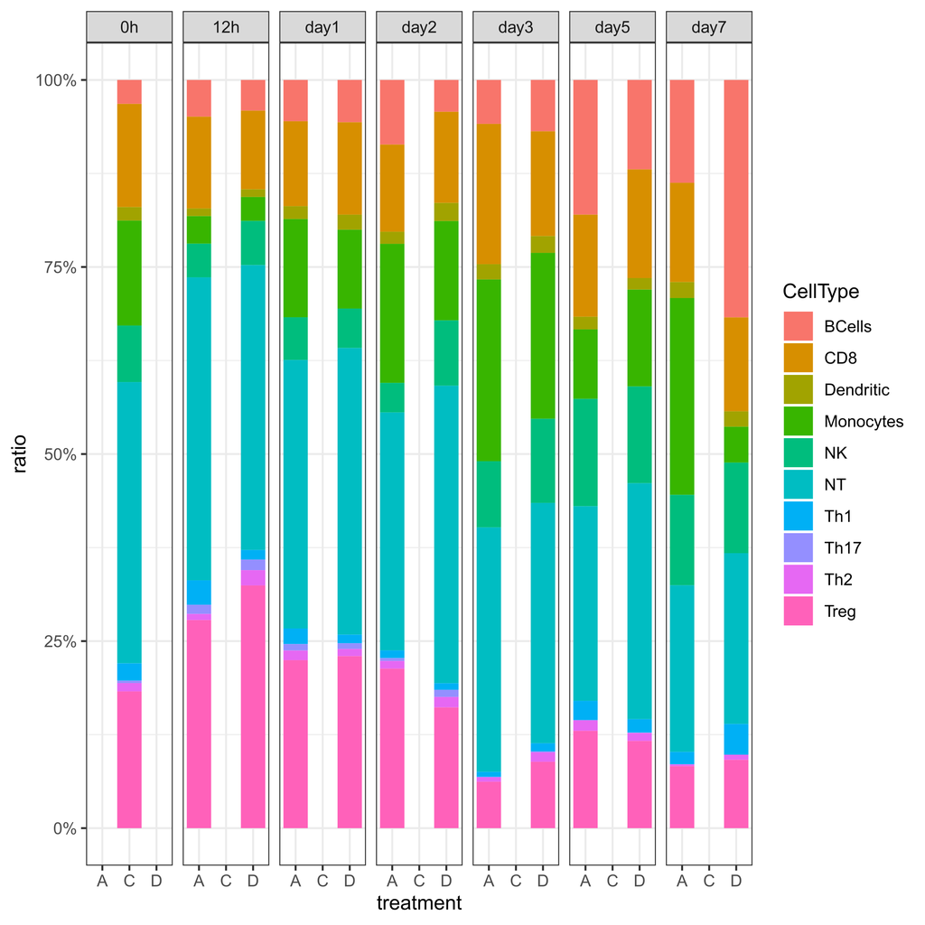

## Upstream Regulatory (UR) gene prediction in Ingenuity Pathway Analysis (IPA)

IPA is a commercial software, but you can request a free trial here (https://digitalinsights.qiagen.com/products-overview/discovery-insights-portfolio/analysis-and-visualization/qiagen-ipa/).

To reproduce the analyses for prediction of URs from our project, follow the following pipeline.

1. Creat a project (eg. SAR) in the Project Manager to upload the DEGs (differentially expressed genes)

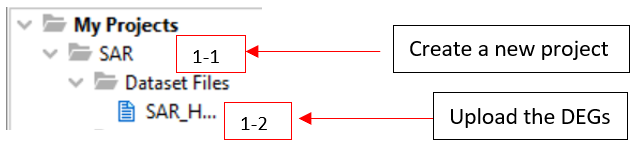

For each list of DEGs, perform step 2 - 8, for UR prediction in IPA. In those cases where >5000 significant DEGs were identified, the DEGs need to be prioritized, due to limitations in IPA. We included the top 5000 DEGs (based on lowest q-value) into the IPA analysis.

2. Upload the DEGs into the project “Dataset Files”, including their corresponding LogFCs and q-values. Based on this data, choose the corresponding ID, “Human gene symbol”, and the observation names, “Expr Log Ratio” (LogFC) and “Expr False Discovery Rate” (q-val). Keep both LogFC and q-val as the same group, “observation 1”. ”Save” and name the dataset.

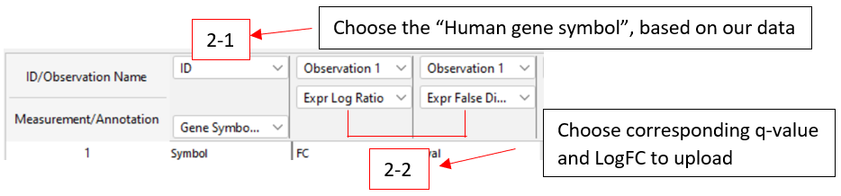

3. In the lower right corner, click “Analyze/Filter Dataset” and then “Core Analysis” to perform IPA analysis of the data.

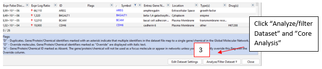

4. Click ”next”, to get to the settings.

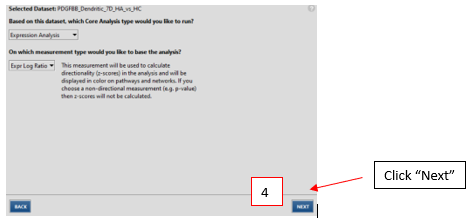

5. In the settings. based on this dataset, define “General settings - Species” = Human, “Node Types” = All, “Data Sources” = All, “Tissues&Cell Lines” = All, and “Mutation” = All.
6. Run the analyses by “Run Analysis”.

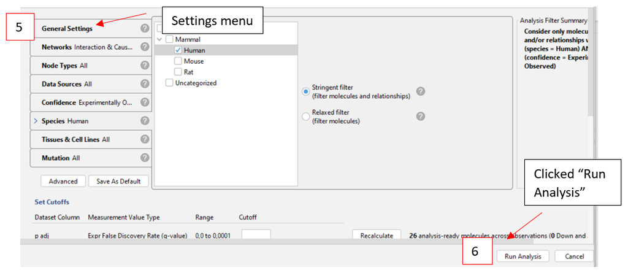

7. All the performed analyses can be found in the “SAR” project under “Analyses”. Choose one of the analyses to check the results.

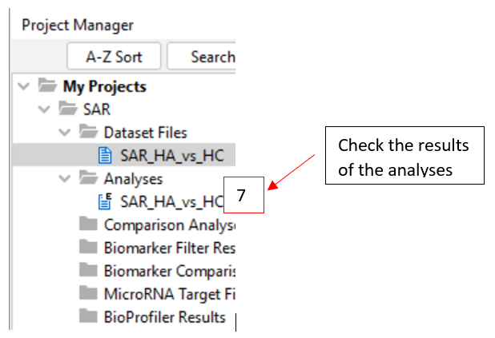

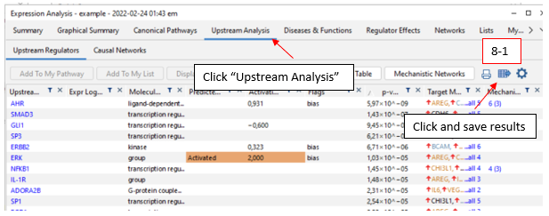

## Construction of multicellular network models (MNMs) and ranking of URs

To run the whole pipeline, on the example data-set, after IPA UR prediction, run post_IPA.sh

> ./post_IPA.sh

### MNM construction

The MNMs are constructed for each time point by running MNM_construction.R in R 4.0. Input to this script are the UR predictions from IPA and the list of DEGs. For the script to run smoothly, ensure that the input directory comtaining the UR predictions from IPA includes one subdirectory per time point, which in turn should include only, but all, the files to construct the MNMs. Additionally, ensure that the directory containing the DEGs includes only, but all, the files for MNM construction. See ‘Rscript MNM_construction.R –help’ for more details.

> Rscript MNM_construction.R ../example_data/IPA_UR-prediction ../example_data/DEGs ../output

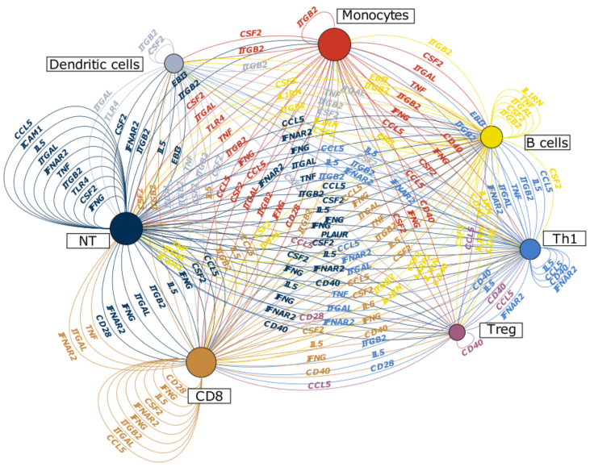

Fig 3. eg. MNM at 0h, illustrated using cytoscape (https://cytoscape.org/).

### Ranking of URs

The URs from the IPA predictions are ranked based on the number of cell types and time points in which they were predicted, by running UR_ranking.R in R 4.0. Input to this script are the UR predictions from IPA. The structure of the data should be the same as for MNM construction, with one subdirectory per time point. See ‘Rscript UR_ranking.R –help’ for more details.

> Rscript UR_ranking.R ../example_data/IPA_UR-prediction ../output

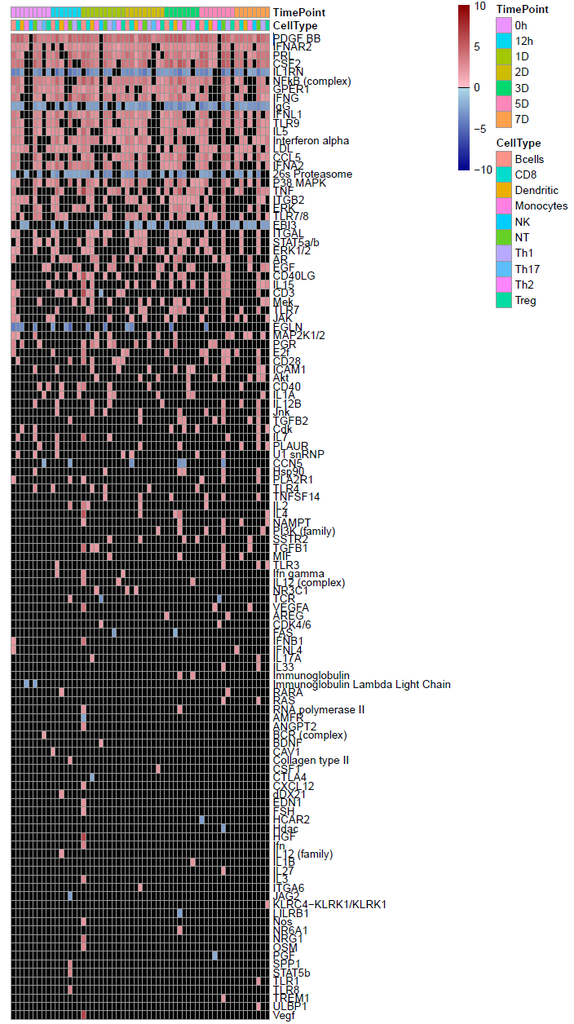

Fig 4. Heatmap with rank-ordered URs in rows and all the cell types over all time points in columns.